# T-ALL Visualization

Yuting Dai

2022-11-19

### Data description

In this tutorial, we provided three demo files `demo.meta.data`, `demo.mut.data` and `demo.exp.data`.

- **demo.meta.data**: storing clinical information and genetic features of T-ALL patients. In the file “demo.meta.data”, rows indicate patients and columns indicate features (such as age, gender).
- **demo.mut.data**: mutations profile of T-ALL patients.
- **demo.exp.data**: storing expression profile of T-ALL patients. In this file, rows indicate the expression level of genes (genes with top variance) and columns indicate patients. In both of the two files, patients were ranked in the same order.

All demo data in this tutorial could be downloaded via GitHub: https://github.com/ytdai/ytdai.github.io/tree/master/T_ALL_viz/data

### Library packages and load data

```r
# library packages
library(ggplot2)
library(ggpubr)
library(ggthemes)
library(pheatmap)
library(Rtsne)
library(scatterplot3d)
library(destiny)
library(configr)

# To download gvmap, please go to:
# https://github.com/ytdai/gvmap
library(gvmap)
# Expression profile with top 5% variance genes
demo.exp.data <- readRDS("data/Demo.exp.data.RDS")
# Meta information of T-ALL patients
demo.meta.data <- readRDS("data/Demo.meta.data.RDS")
# Mutation profile of T-ALL patients
demo.mut.data <- readRDS("data/Demo.mut.data.RDS")

dim(demo.exp.data)
```

```
## [1] 939 200
```

```r
dim(demo.meta.data)
```

```
## [1] 200  28
```

```r
head(demo.exp.data[, 1:10])
```

```
##           TALL_1    TALL_2    TALL_3   TALL_4    TALL_5     TALL_6    TALL_7
## H2AC18  6.355412 10.029167 7.0002368 5.979887 0.0000000  0.0000000 0.0000000
## ALDH1A2 6.033784  4.375378 4.9714803 6.285723 2.8443502  1.7634126 3.6826440
## CD1E    4.634718  7.665006 6.2314511 7.985121 4.5388290  7.5312902 7.9085795
## SIX6    1.796949  1.796949 1.7969486 1.796949 0.9850909 -0.4173334 0.9850909
## CD1B    4.822551  4.743648 6.1757738 8.105523 3.7972293  3.3481952 5.2250221
## MYO18B  1.685803  2.060090 0.8358973 3.147926 4.4740458  3.2404395 2.9135200
##             TALL_8     TALL_9  TALL_10
## H2AC18   0.0000000  0.0000000 0.000000
## ALDH1A2  2.1588201 10.8130610 4.946257
## CD1E     3.1712300 12.9037208 4.598782
## SIX6    -0.4173334  0.7040543 1.796949
## CD1B     3.3640379 12.7795470 5.300626
## MYO18B   4.0204398  2.6682208 5.097854
```

```r
head(demo.meta.data)
```

```
##            ID Group Gender   Age ETP.status.mod Tcell.status.mod OS.event
## TALL_1 TALL_1    G1 Female Adult       undefine      Procortical       NA
## TALL_2 TALL_2    G1   Male Adult       undefine      Procortical        1
## TALL_3 TALL_3    G1 Female Adult       undefine         undefine       NA
## TALL_4 TALL_4    G1   Male Adult       undefine      Procortical       NA
## TALL_5 TALL_5    G1   Male Adult       undefine         undefine       NA
## TALL_6 TALL_6    G1   Male Adult            ETP         undefine        0
##        SET_NUP214 NUP98_fus SPI1_fus KMT2A_r MLLT10_r HOXA10_r TLX3_fus
## TALL_1          0         0        0       0        0        0        0
## TALL_2          0         0        0       0        0        0        0
## TALL_3          0         1        0       0        0        0        0
## TALL_4          0         0        0       0        0        0        0
## TALL_5          0         0        0       0        0        0        0
## TALL_6          1         0        0       0        0        0        0
##        TLX1_fus NKX_fus STIL_TAL1 TAL1_fus TAL2_fus LMO2_fus ABL1_fus
## TALL_1        0       0         0        0        0        0        0
## TALL_2        0       0         0        0        0        0        0
## TALL_3        0       0         0        0        0        0        0
## TALL_4        0       0         0        0        0        0        0
## TALL_5        0       0         0        0        0        0        0
## TALL_6        0       0         0        0        0        0        0
##        ZFP36L2_fus OtherFus GATA3_mut RPL10_mut DNMT3A_mut IDH2_mut NRAS_mut
## TALL_1           0        0         0         0          1        1        1
## TALL_2           0        1         0         0          1        1        1
## TALL_3           0        0         0         0          0        0        1
## TALL_4           0        0         0         0          1        0        0
## TALL_5           0        0         0         0          1        0        0
## TALL_6           0        0         0         0          0        1        0
```

### Dimensionality reduction

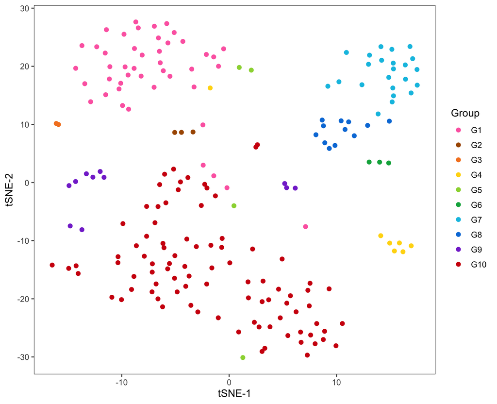

```r
##################
# definition of colors
color.group <- c("#FD6AB0","#AA5700","#F48326","#FFD711","#9BD53F","#00AE4C","#00C1E3","#007DDB","#8538D1","#D01910")
names(color.group) <- c(paste0("G", 1:10))

color.etp <- c("#D01910","#00599F","#CCCCCC")
names(color.etp) <- c("ETP","notETP","undefine")

color.tcell <- c("#B2DF8A", "#33A02C","#1F78B4","#A6761D","#E31A1C","#CCCCCC")
names(color.tcell) <- c("Procortical","Precortical","Cortical","Postcortical","Medullary","undefine")

##################
# Run tsne
perplexity = 15
theta = 0.2
set.seed(1)
tsne.out <- Rtsne(t(demo.exp.data), perplexity = perplexity, theta = theta, dims = 2)
colnames(tsne.out$Y) <- c("tSNE1", "tSNE2")

plot.info <- as.data.frame(cbind(tsne.out$Y, demo.meta.data[, c("ID","Group","Age","Gender")]))
p <- ggscatter(plot.info,
               x = "tSNE1", y = "tSNE2",
               color = "Group", fill = "Group",
               palette = color.group,
               xlab = "tSNE-1", ylab = "tSNE-2")
p <- p + theme_few()
p
```

```r
##################
# Run PCA
res.pca.comp <- prcomp(demo.exp.data, scale = TRUE)

plot.data <- as.data.frame(res.pca.comp$rotation[, 1:10])
plot.data$ID = rownames(plot.data)
sum(plot.data$ID != demo.meta.data$ID)
```

```
## [1] 0
```

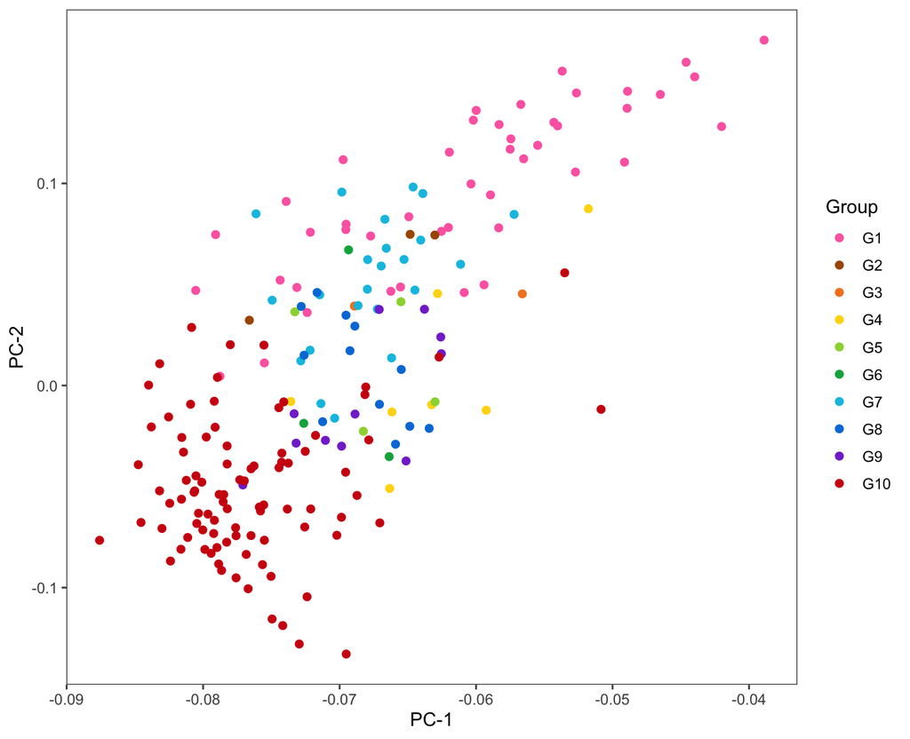

```r
plot.data$Group <- demo.meta.data$Group

p <- ggscatter(plot.data,
               x = "PC1", y = "PC2",
               color = "Group", fill = "Group",
               palette = color.group,
               xlab = "PC-1", ylab = "PC-2")
p <- p + theme_few()
p
```

```r
##################
# Diffusion map
dm.data <- as.matrix(scale(t(demo.exp.data)))
sigma.use <- find_sigmas(dm.data, verbose = FALSE)@optimal_sigma
plot.data <- DiffusionMap(dm.data, sigma = sigma.use, k = 10,
                          density_norm = TRUE, distance = "euclidean",
                          n_pcs = 30 )
```

```
## as(<dsCMatrix>, "dgTMatrix") is deprecated since Matrix 1.5-0; do as(as(., "generalMatrix"), "TsparseMatrix") instead
```

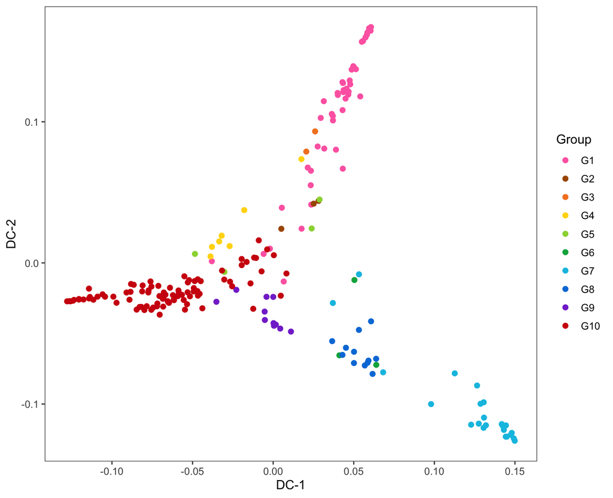

```r
colnames(plot.data@eigenvectors) <- paste0("DC_", seq_len(ncol(plot.data@eigenvectors)))

plot.data <- as.data.frame(plot.data@eigenvectors)
plot.data$ID <- demo.meta.data$ID
plot.data$Group <- demo.meta.data$Group
p <- ggscatter(plot.data,
               x = "DC_1", y = "DC_2",
               color = "Group", fill = "Group",
               palette = color.group,
               xlab = "DC-1", ylab = "DC-2")
p <- p + theme_few()
p
```

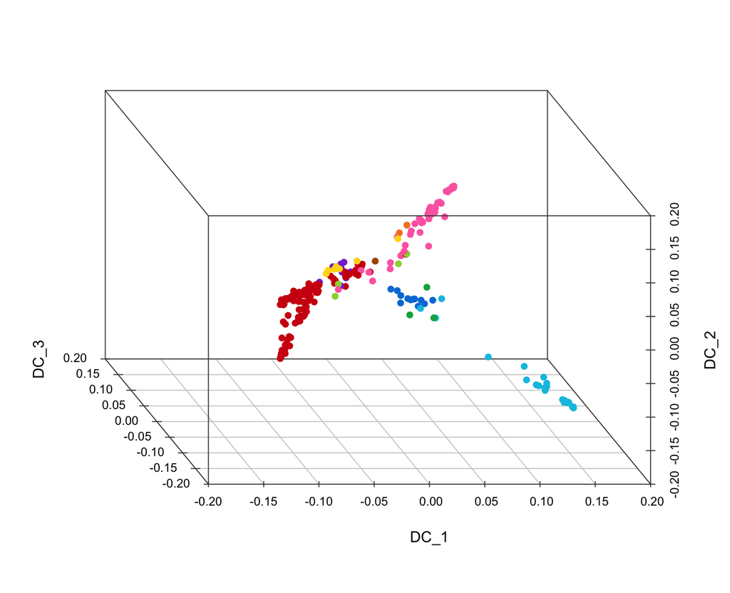

```r
plot.data$color <- color.group[as.numeric(as.factor(plot.data$Group))]
scatterplot3d(x = plot.data$DC_1,
              y = plot.data$DC_3,
              z = plot.data$DC_2,
              color = plot.data$color,
              pch = 16, cex.symbols = 1,
              scale.y = 0.7, angle = 120,
              xlab = "DC_1", ylab = "DC_3", zlab = "DC_2",
              col.axis = "#444444", col.grid = "#CCCCCC")
```

### Heatmap and mutation profile visualization

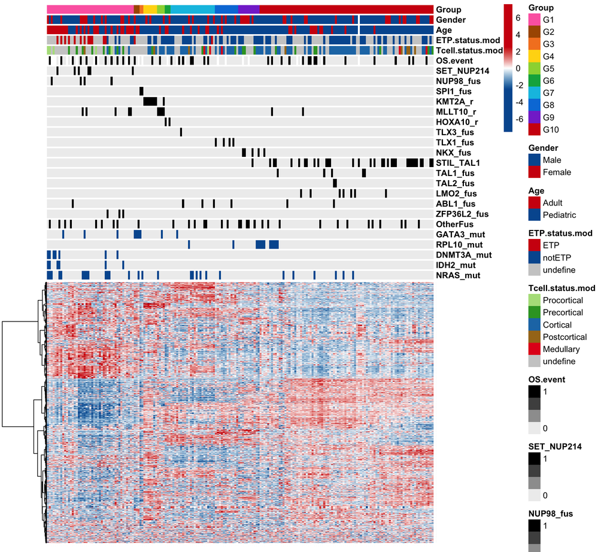

```r
##################
# heatmap
anno.col <- demo.meta.data[, rev(colnames(demo.meta.data)[2:ncol(demo.meta.data)])]
anno.col.color <- list(Age = c(Adult = "#D01910", Pediatric = "#00599F"),
                       Gender = c(Male = "#00599F", Female = "#D01910"),
                       ETP.status.mod = color.etp,
                       Tcell.status.mod = color.tcell,
                       OS.event = c("#EEEEEE","#000000"),
                       SET_NUP214 = c("#EEEEEE","#000000"),
                       NUP98_fus = c("#EEEEEE","#000000"),
                       SPI1_fus = c("#EEEEEE","#000000"),
                       KMT2A_r = c("#EEEEEE","#000000"),
                       MLLT10_r = c("#EEEEEE","#000000"),
                       HOXA10_r = c("#EEEEEE","#000000"),
                       TLX3_fus = c("#EEEEEE","#000000"),
                       TLX1_fus = c("#EEEEEE","#000000"),
                       NKX_fus = c("#EEEEEE","#000000"),
                       STIL_TAL1 = c("#EEEEEE","#000000"),
                       TAL1_fus = c("#EEEEEE","#000000"),
                       TAL2_fus = c("#EEEEEE","#000000"),
                       LMO2_fus = c("#EEEEEE","#000000"),
                       ABL1_fus = c("#EEEEEE","#000000"),
                       ZFP36L2_fus = c("#EEEEEE","#000000"),
                       OtherFus = c("#EEEEEE","#000000"),
                       GATA3_mut = c("#EEEEEE","#00599F"),
                       RPL10_mut = c("#EEEEEE","#00599F"),
                       DNMT3A_mut = c("#EEEEEE","#00599F"),
                       IDH2_mut = c("#EEEEEE","#00599F"),
                       NRAS_mut = c("#EEEEEE","#00599F"),
                       Group = color.group)

p <- pheatmap(as.matrix(demo.exp.data), scale = "row",
              color = colorRampPalette(c("#00599F","#00599F","#00599F","white","#D01910","#D01910","#D01910"))(501),
              cluster_row = T, cluster_col = F, border_color = NA,
              annotation_col = anno.col,
              annotation_colors = anno.col.color,
              clustering_method = "ward.D",
              clustering_distance_rows = "euclidean",
              fontsize_col = 0.1,
              fontsize_row = 0.1)
```

Config file could be downloaded via `config_file_content`

```r
##################
# heatmap
config_file_content <- "data/config.allsample.fig.basic.yaml"

config_file_content <- read.config(config_file_content)
config_file_content <- gvmapModAttr(attr_name = "legend_num", value = 2, config_file = config_file_content)
config_file_content <- gvmapModAttr(attr_name = "heatmap_num", value = 0, config_file = config_file_content)
config_file_content <- gvmapModAttr(attr_name = "percentage", value = 0.1, target = "heatmap_1", config_file = config_file_content)
config_file_content <- gvmapModAttr(attr_name = "map_order",
                                    value = c("legend_1","legend_2"),
                                    config_file = config_file_content)


leg_value_col_1 <- c("Group", "Age", "Gender")
leg_value_name_1 <- c("Subgroup", "Age", "Gender")
leg_value_1 <- data.frame(name = leg_value_name_1,
                          color = c("pool_col","pool_age_col", "pool_gender_col"),
                          column = match(leg_value_col_1, colnames(demo.mut.data)))
config_file_content <- gvmapModAttr(target = "legend_1", attr_name = "legend", value = leg_value_1, config_file = config_file_content)


leg_value_col_2 <- c("NOTCH1","FBXW7","PHF6","PTEN","DNM2","NRAS","JAK3","BCL11B","USP7","GATA3",
                     "NOTCH_sig","Epi","IF","PI3K","JAK_STAT","RAS_sig","Translation","CellCycle","Other")
leg_value_2 <- data.frame(name = leg_value_col_2,
                          color = "mutation_col",
                          column = match(leg_value_col_2, colnames(demo.mut.data)))
config_file_content <- gvmapModAttr(target = "legend_2", attr_name = "legend", value = leg_value_2, config_file = config_file_content)

output_svg_name <- paste0("data/mutation.pathway.svg")

gvmap(legend_data = demo.mut.data,
      config_file = config_file_content,
      output_svg_name = output_svg_name,
      stroke_width = 0,
      dend_stroke_width = 1,
      frame_stroke_width = 1,
      sample_span = 2,
      group_span = 5,
      sample_font_size = 2,
      output_group_info = T,
      convert_pdf = T,
      plot_height = 1000)
```

```
## [INFO] You have input a list config file
```

```
## [INFO] Read config data completed
```

```
## [INFO] Read legend data completed
```

```
## [WARNING] heatmap data is missing.
```

```
## [INFO] Read heatmap data completed
```

```
## [INFO] Generating plot paramters completed
```

```
## [INFO] Preprocessing heatmap data
```

```
## [INFO] Preprocessing legend data
```

```
## [INFO] Start to generating SVG element
```

```
## [INFO] Start to generating SVG element location
```

```
## [INFO] Output SVG
```

The output SVG file could be downloaded from `gvmap output result`.

[figure not shown]

gvmap output

### Reference and citation

Please cite:

[1] Dai YT, Zhang F, Fang H, Li JF, Lu G, Jiang L, Chen B, Mao DD, Liu YF, Wang J, et al: Transcriptome-wide subtyping of pediatric and adult T cell acute lymphoblastic leukemia in an international study of 707 cases. Proc Natl Acad Sci U S A 2022, 119:e2120787119.